# *Assignment #2*

## **[CSCI 581](https://www.ecst.csuchico.edu/~bjuliano/csci581/)**, Spring 2022

Jayaa Emekar

# **Instructions**

In this assignment, you will be using the [*ACME Sales*](https://www.ecst.csuchico.edu/~bjuliano/csci581/datasets/acme_sales.csv) dataset to generate visualizations. Each question below asks you to provide a code section that will generate the requested chart type.

For full credit, make sure that each chart you generate

- has an appropriate title that clearly describes the information presented
- uses relevant labels for each axis
- deviates from any default style setting by changing the default (line/bar) color, marker shape, marker color, line width, or other feature
- uses any additional chart feature that will enhance the information your visualization is attempting to convey.

You are free to choose using [`matplotlib`](https://matplotlib.org/) or [`seaborn`](https://seaborn.pydata.org/) or any other library to generate your visualization.

To get you started, the following code loads the [*ACME Sales*](https://www.ecst.csuchico.edu/~bjuliano/csci581/datasets/acme_sales.csv) dataset into a [`pandas`](https://pandas.pydata.org/) `DataFrame` object and uses *Google Colab*'s interactive table feature to show you what the data looks like:

```python
import pandas as pd
import matplotlib.pyplot as plt
from google.colab import data_table

# Load the required dataset into a dataframe, df
df = pd.read_csv('https://www.ecst.csuchico.edu/~bjuliano/csci581/datasets/acme_sales.csv')

# Set up to use Google Colab's interactive tables feature
data_table.enable_dataframe_formatter()

# Display the interactive table
df
```

|  | month_number | facecream | facewash | toothpaste | bathsoap | shampoo | moisturizer | total_units | total_profit |
| --- | --- | --- | --- | --- | --- | --- | --- | --- | --- |
| 0 | 1 | 2500 | 1500 | 5200 | 9200 | 1200 | 1500 | 21100 | 211000 |
| 1 | 2 | 2630 | 1200 | 5100 | 6100 | 2100 | 1200 | 18330 | 183300 |
| 2 | 3 | 2140 | 1340 | 4550 | 9550 | 3550 | 1340 | 22470 | 224700 |
| 3 | 4 | 3400 | 1130 | 5870 | 8870 | 1870 | 1130 | 22270 | 222700 |
| 4 | 5 | 3600 | 1740 | 4560 | 7760 | 1560 | 1740 | 20960 | 209600 |
| 5 | 6 | 2760 | 1555 | 4890 | 7490 | 1890 | 1555 | 20140 | 201400 |
| 6 | 7 | 2980 | 1120 | 4780 | 8980 | 1780 | 1120 | 29550 | 295500 |
| 7 | 8 | 3700 | 1400 | 5860 | 9960 | 2860 | 1400 | 36140 | 361400 |
| 8 | 9 | 3540 | 1780 | 6100 | 8100 | 2100 | 1780 | 23400 | 234000 |
| 9 | 10 | 1990 | 1890 | 8300 | 10300 | 2300 | 1890 | 26670 | 266700 |
| 10 | 11 | 2340 | 2100 | 7300 | 13300 | 2400 | 2100 | 41280 | 412800 |
| 11 | 12 | 2900 | 1760 | 7400 | 14400 | 1800 | 1760 | 30020 | 300200 |

# 1. Generate a line chart showing the company's total profit per month.

## Solution:

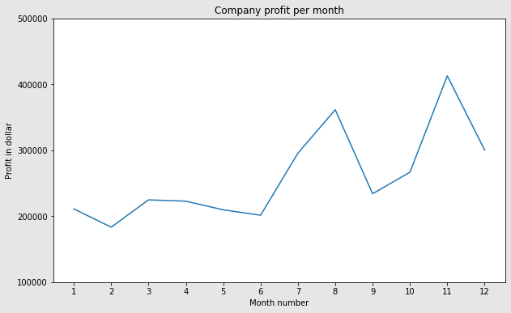

```python
#Generate a line chart showing the company's total profit per month.
#Get data for month and profit
profitList = df ['total_profit'].tolist()
monthList  = df ['month_number'].tolist()

#Plot data for month and profit
plt.figure(figsize=(10, 6), facecolor='0.9')
plt.plot(monthList, profitList, label = 'Month-wise Profit data of last year')
plt.xlabel('Month number')
plt.ylabel('Profit in dollar')
plt.xticks(monthList)
plt.title('Company profit per month')
plt.yticks([100000, 200000, 300000, 400000, 500000])
plt.show()
```

# 2. Generate a multiline plot (*i.e.*, use a separate plot line for each of the six products) showing the total units sold per month for each product.

## Solution(s)

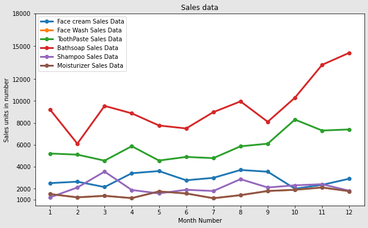

```python
#Generate a multiline plot (i.e., use a separate plot line for each of the six products) showing the total units sold per month for each product
#Get data into variables
monthList  = df ['month_number'].tolist()
faceCremSalesData   = df ['facecream'].tolist()
faceWashSalesData   = df ['facewash'].tolist()
toothPasteSalesData = df ['toothpaste'].tolist()
bathingsoapSalesData   = df ['bathsoap'].tolist()
shampooSalesData   = df ['shampoo'].tolist()
moisturizerSalesData = df ['moisturizer'].tolist()

# Plot the multiline plot
plt.figure(figsize=(10, 6), facecolor='0.9')
plt.plot(monthList, faceCremSalesData,   label = 'Face cream Sales Data', marker='o', linewidth=3)
plt.plot(monthList, faceWashSalesData,   label = 'Face Wash Sales Data',  marker='o', linewidth=3)
plt.plot(monthList, toothPasteSalesData, label = 'ToothPaste Sales Data', marker='o', linewidth=3)
plt.plot(monthList, bathingsoapSalesData, label = 'Bathsoap Sales Data', marker='o', linewidth=3)
plt.plot(monthList, shampooSalesData, label = 'Shampoo Sales Data', marker='o', linewidth=3)
plt.plot(monthList, moisturizerSalesData, label = 'Moisturizer Sales Data', marker='o', linewidth=3)


plt.xlabel('Month Number')
plt.ylabel('Sales units in number')
plt.legend(loc='upper left')
plt.xticks(monthList)
plt.yticks([1000, 2000, 4000, 6000, 8000, 10000, 12000, 15000, 18000])
plt.title('Sales data')
plt.show()
```

# 3. Generate a scatter plot that shows the toothpaste sales data for each month.

## Solution(s)

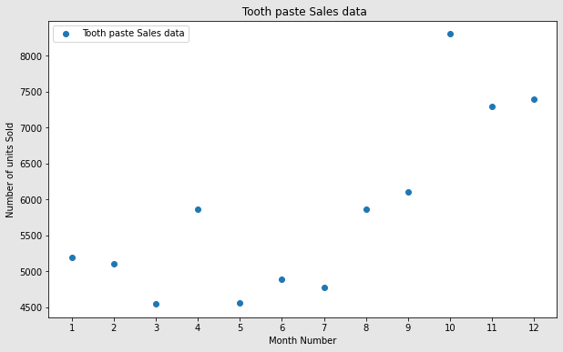

```python
#Generate a scatter plot that shows the toothpaste sales data for each month.
monthList  = df ['month_number'].tolist()
toothPasteSalesData = df ['toothpaste'].tolist()

#plot the scatter plot
plt.figure(figsize=(10, 6), facecolor='0.9')
plt.scatter(monthList, toothPasteSalesData, label = 'Tooth paste Sales data')
plt.xlabel('Month Number')
plt.ylabel('Number of units Sold')
plt.legend(loc='upper left')
plt.title(' Tooth paste Sales data')
plt.xticks(monthList)
plt.show()
```

# 4. Generate a bar chart showing the face cream and face wash sales per month. Use a separate bar for each product in the same chart.

## Solution(s)

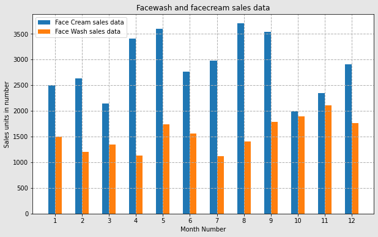

```python
# gather the data from dataset
monthList  = df ['month_number'].tolist()
faceCremSalesData   = df ['facecream'].tolist()
faceWashSalesData   = df ['facewash'].tolist()

#plot the Facewash and facecream sales data
plt.figure(figsize=(10, 6), facecolor='0.9')
plt.bar([a-0.25 for a in monthList], faceCremSalesData, width= 0.25, label = 'Face Cream sales data', align='edge')
plt.bar([a+0.25 for a in monthList], faceWashSalesData, width= -0.25, label = 'Face Wash sales data', align='edge')
plt.xlabel('Month Number')
plt.ylabel('Sales units in number')
plt.legend(loc='upper left')
plt.title(' Sales data')

plt.xticks(monthList)
plt.grid(True, linewidth= 1, linestyle="--")
plt.title('Facewash and facecream sales data')
plt.show()
```

# 5. Generate a pie chart showing the sales proportion of each product for the total sale for the year. Explode the slice that has the highest proportion.

## Solution(s)

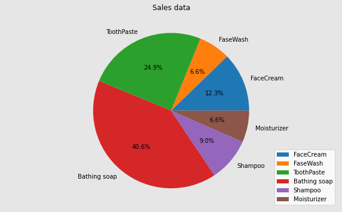

```python
#Generate a pie chart showing the sales proportion of each product for the total sale for the year.
#Explode the slice that has the highest proportion.
monthList  = df ['month_number'].tolist()

plt.figure(figsize=(10, 6), facecolor='0.9')
labels = ['FaceCream', 'FaseWash', 'ToothPaste', 'Bathing soap', 'Shampoo', 'Moisturizer']
salesData   = [df ['facecream'].sum(), df ['facewash'].sum(), df ['toothpaste'].sum(),
         df ['bathsoap'].sum(), df ['shampoo'].sum(), df ['moisturizer'].sum()]
plt.axis("equal")
plt.pie(salesData, labels=labels, autopct='%1.1f%%')
plt.legend(loc='lower right')
plt.title('Sales data')
plt.show()
```

Bathing soap has highest contribution which is equal to 40.6%

# Notes

## *(Optional)* Include any final thoughts, comments, or observations here, if applicable.